# Lab-9

### Dev Bharatbhai Patel (8938546)

### Lab-9

#### 1. Using Keras Datasets, obtain the fMNIST data set. Explore and describe it as you would do with any new dataset that you start working with

```python
!pip install pandas
import pandas as pd
```

[output not shown]

[output not shown]

```python
# Importing necessary Packages
from tensorflow.keras.datasets import fashion_mnist
import matplotlib.pyplot as plt
import numpy as np

from tensorflow.keras.models import Sequential
from tensorflow.keras.layers import Dense, Flatten
from sklearn.metrics import confusion_matrix ,classification_report
```

```python
# Loading the Fashion MNIST dataset
(train_images, train_labels), (test_images, test_labels) = fashion_mnist.load_data()
```

```python
# Exploring the dataset
print("Training Images Set Shape:", train_images.shape)
print("Number of Training Images Samples:", len(train_images))
print("Image dimensions:", train_images[0].shape)

print("\nTest Images Set Shape:", test_images.shape)
print("Number of Test Images Samples:", len(test_images))
print("Image dimensions:", test_images[0].shape)
```

```
Training Images Set Shape: (60000, 28, 28)
Number of Training Images Samples: 60000
Image dimensions: (28, 28)

Test Images Set Shape: (10000, 28, 28)
Number of Test Images Samples: 10000
Image dimensions: (28, 28)
```

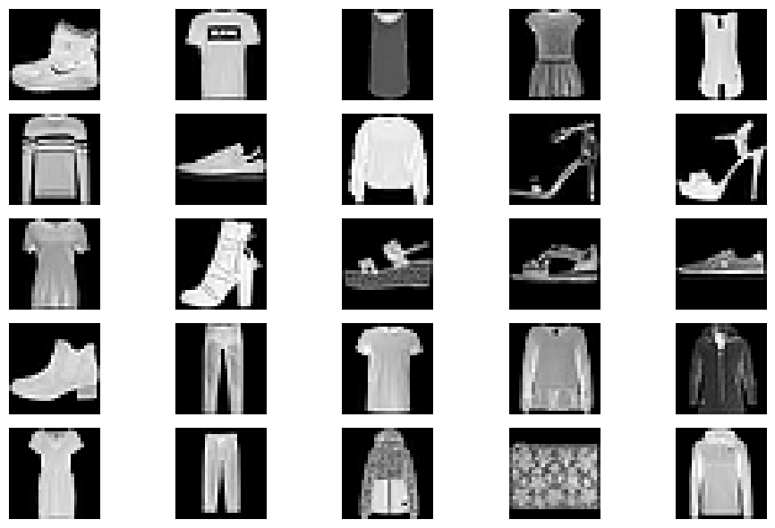

```python
# Displaying some images from the dataset
fig, axes = plt.subplots(5, 5, figsize=(10, 6))
axes = axes.ravel()

for i in np.arange(25):
    axes[i].imshow(train_images[i], cmap='gray')
    axes[i].axis('off')

plt.tight_layout()
plt.show()
```

- Grayscale photos of various fashion items are included in the fMNIST dataset, which is an adaptation of the popular MNIST dataset.
- The dataset contains grayscale images of 10 different categories of fashion items.
- It contains **60,000** sample images of training and **10,000** sample images of testing data and each images occupy a space of **28x28** pixels.

#### 2. Train a dense neural network using Keras, try out at least three hyperparameters configurations

```python
# Normalizing the image's pixels value to the range of [0,1]
train_images = train_images.astype("float32") / 255.0
test_images = test_images.astype("float32") / 255.0

# Now, flattening the images for the dense neural network
train_images = train_images.reshape((60000, 28*28))
test_images = test_images.reshape((10000, 28*28))
```

- Model-1
  - Training the 1st model by taking **128** as an input.

```python
DNN_model1 = Sequential([
        Dense(128, activation='relu'),
        Flatten(input_shape=(train_images.shape[1],)),
        Dense(512, activation='relu'),
        Dense(64, activation='relu'),
        Dense(10, activation='softmax')
    ])
DNN_model1.compile(optimizer='adam', loss='sparse_categorical_crossentropy', metrics=['accuracy'])
print("Model-1")
DNN_model1.fit(train_images,train_labels, epochs=20)
```

```
Model-1
```

```
<keras.callbacks.History at 0x1f6f97c7750>
```

- Model-2
  - Training the 2nd model by taking **512** as an input

```python
DNN_model2 = Sequential([
        Dense(512, activation='relu'),
        Flatten(input_shape=(train_images.shape[1],)),
        Dense(64, activation='relu'),
        Dense(32, activation='relu'),
        Dense(10, activation='softmax')
    ])
DNN_model2.compile(optimizer='adam', loss='sparse_categorical_crossentropy', metrics=['accuracy'])
print("Model-2:")
history2 = DNN_model2.fit(train_images,train_labels, epochs=15)
```

```
Model-2:
```

- Model-3
  - Training 3rd model by taking **32** as an input

```python
DNN_model3 = Sequential([
        Dense(32, activation='relu'),
        Flatten(input_shape=(train_images.shape[1],)),
        Dense(32, activation='relu'),
        Dense(10, activation='softmax')
    ])
DNN_model3.compile(optimizer='adam', loss='sparse_categorical_crossentropy', metrics=['accuracy'])
print("Model-3:")
DNN_model3.fit(train_images,train_labels, epochs=10)
```

```
Model-3:
```

```
<keras.callbacks.History at 0x1f680c1bcd0>
```

#### 3. Evaluate its accuracy for each of the configurations. Choose the best configuration, and: Report its accuracy, confusion metric, and specific examples of incorrect classification, and drew some conclusions from this exploration

- Checking the accuracy for each of the configurations.

```python
def prediction_model(model, x_image):
    y_pred = np.argmax(model.predict(x_image.reshape((-1, 28 * 28))), axis=1)
    return y_pred

def model_evaluation(y_pred , y_test):
    report = classification_report(y_test, y_pred,output_dict=True)
    return (report)
```

```python
y_pred_1 = prediction_model(DNN_model1, test_images)
print("Model-1:",pd.DataFrame(model_evaluation(y_pred_1, test_labels)).T)
```

```
Model-1:               precision  recall  f1-score     support
0              0.813384  0.8630  0.837458   1000.0000
1              0.986895  0.9790  0.982932   1000.0000
2              0.785108  0.8330  0.808345   1000.0000
3              0.917794  0.8820  0.899541   1000.0000
4              0.789134  0.8570  0.821668   1000.0000
5              0.968411  0.9810  0.974665   1000.0000
6              0.766784  0.6510  0.704164   1000.0000
7              0.946026  0.9640  0.954928   1000.0000
8              0.983773  0.9700  0.976838   1000.0000
9              0.972222  0.9450  0.958418   1000.0000
accuracy       0.892500  0.8925  0.892500      0.8925
macro avg      0.892953  0.8925  0.891896  10000.0000
weighted avg   0.892953  0.8925  0.891896  10000.0000
```

```python
y_pred_2 = prediction_model(DNN_model2, test_images)
print("Model-2:",pd.DataFrame(model_evaluation(y_pred_2, test_labels)).T)
```

```
Model-2:               precision  recall  f1-score   support
0              0.784192   0.883  0.830668   1000.00
1              0.960746   0.979  0.969787   1000.00
2              0.871338   0.684  0.766387   1000.00
3              0.901235   0.876  0.888438   1000.00
4              0.786398   0.821  0.803327   1000.00
5              0.985462   0.949  0.966887   1000.00
6              0.675808   0.690  0.682830   1000.00
7              0.925822   0.986  0.954964   1000.00
8              0.955209   0.981  0.967933   1000.00
9              0.972393   0.951  0.961577   1000.00
accuracy       0.880000   0.880  0.880000      0.88
macro avg      0.881860   0.880  0.879280  10000.00
weighted avg   0.881860   0.880  0.879280  10000.00
```

```python
y_pred_3 = prediction_model(DNN_model3, test_images)
print("Model-3",pd.DataFrame(model_evaluation(y_pred_3, test_labels)).T)
```

```
Model-3               precision  recall  f1-score    support
0              0.864212   0.751  0.803638   1000.000
1              0.984725   0.967  0.975782   1000.000
2              0.848635   0.684  0.757475   1000.000
3              0.902023   0.847  0.873646   1000.000
4              0.696193   0.896  0.783559   1000.000
5              0.967280   0.946  0.956522   1000.000
6              0.636687   0.715  0.673575   1000.000
7              0.899261   0.973  0.934678   1000.000
8              0.975635   0.961  0.968262   1000.000
9              0.969442   0.920  0.944074   1000.000
accuracy       0.866000   0.866  0.866000      0.866
macro avg      0.874409   0.866  0.867121  10000.000
weighted avg   0.874409   0.866  0.867121  10000.000
```

- From the above models accuracy **Model-1** has the best accuracy among other model.
- Its accuracy is **89%**.

```python
confusion_matrix(y_pred_1, test_labels)
```

```
array([[863,   3,  19,  21,   2,   0, 150,   0,   3,   0],
       [  3, 979,   1,   7,   1,   0,   1,   0,   0,   0],
       [ 27,   0, 833,  20,  88,   0,  88,   0,   5,   0],
       [ 14,  12,   9, 882,  22,   0,  18,   0,   4,   0],
       [  5,   2,  87,  44, 857,   0,  87,   0,   4,   0],
       [  0,   2,   0,   0,   0, 981,   0,  14,   1,  15],
       [ 83,   2,  51,  22,  29,   0, 651,   0,  10,   1],
       [  0,   0,   0,   0,   0,  13,   0, 964,   3,  39],
       [  5,   0,   0,   4,   1,   1,   5,   0, 970,   0],
       [  0,   0,   0,   0,   0,   5,   0,  22,   0, 945]], dtype=int64)
```

- This is the confusion matrix of Model-1.
- Speicfic Example of incorrect classification

```python
incorrect_classification = np.where(test_labels != y_pred_1)[0]
incorrect_classification
```

```
array([   4,   17,   23, ..., 9972, 9979, 9991], dtype=int64)
```

```
Total number of incorrect indices 1075
```

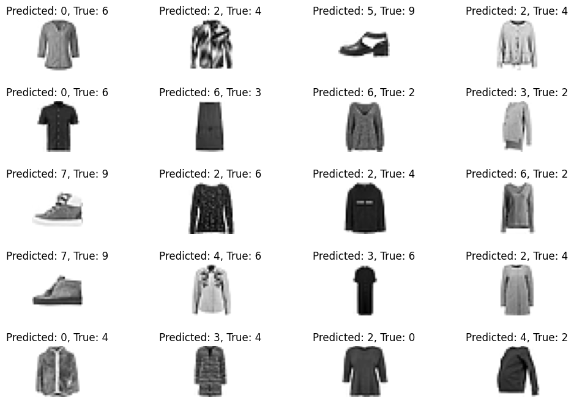

```python
# Get predicted labels for the test set
predicted_labels = DNN_model1.predict(test_images)
predicted_labels = np.argmax(predicted_labels, axis=1)

# indices of misclassified samples
misclassified_indices = np.where(test_labels != predicted_labels)[0]
print('Total number of incorrect indices', len(misclassified_indices))
# misclassified samples with their predicted and true labels
plt.figure(figsize=(12, 8))
for i, idx in enumerate(misclassified_indices[:20]):
    plt.subplot(5, 4, i + 1)
    plt.imshow(test_images[idx].reshape(28, 28) , cmap ="binary")
    plt.title(f"Predicted: {predicted_labels[idx]}, True: {test_labels[idx]}")
    plt.axis('off')

plt.subplots_adjust(wspace=0.4, hspace=0.6)
plt.show()
```

- The model's incorrect input is real and extremely challenging to categorize since certain classes have a great deal of similarities.
- The total number of incorrect index is **1075** which is less compare to others.